# Wooldridge 2010 Examples

George G. Vega Yon

November 4, 2016

# Chapter 22: Duration Analysis

For this chapter we will use the `survival` package (Therneau 2016).

The fundamental question, conditional on having survived at $t$, what is the probability of failure (death) between $(t,t+h]$. This is the hazard function.

$$\begin{align*}
\lambda(t)
\tag{22.3}& = \lim_{h\downarrow 0}\frac{\Pr(t\leq T< t+h|T\geq t)}{h} \\
\tag{22.5}& = \lim_{h\downarrow 0}\frac{F(t+h) - F(t)}{h}\frac{1}{1-F(t)} = \frac{f(t)}{1-F(t)} = \frac{f(t)}{S(t)} \\
\tag{22.6}& = - \frac{d \log S(t)}{d t}
\end{align*}$$

Then, using the fundamental theorem of calculus, we have

$$\begin{align*}
\int_0^t \lambda(s)ds & = -\left[\log(1-F(t)) - \log(1 + F(0))\right] \\
\int_0^t \lambda(s)ds & = -\log S(t) \\
\exp\left[-\int_0^t \lambda(s)ds\right] & = S(t) \\
\end{align*}$$
From eq (22.5)

$$f(t) = \lambda(t)\exp\left[-\int_0^t\lambda(s)ds\right]\tag{22.8}$$

Which implies that we can compute the probabilities using the hazard function.

## Example 22.5: Weibull Model for Recidivism Duration

In the case of the weibull distribution, the cdf conditional on the covariates and the parameters can be written as follows:

$$F(t_i|\mathbf{x}_i;\theta) = 1 - \exp(-\kappa t ^\alpha),\quad\kappa = \exp(\mathbf{x}_i\beta)$$

Since we have censored data, the conditional likelihood for observation $i$ can be written as follows:

$$f(t_i|\mathbf{x}_i;\theta)^{d_i}\left[1 - F(t_i|\mathbf{x}_i;\theta)\right]^{(1-d_i)}\tag{22.23}$$

where $d_i=1$ iff the observation is uncensored, and $1-F(t_i|\mathbf{x}_i;\theta)$ is the probability that observation $i$ is censored. Under weibull we have

$$f(t_i|\mathbf{x}_i;\theta) = \exp(\mathbf{x}_i\beta)\alpha t^{\alpha-1}\exp\left[-\exp(\mathbf{x}_i\beta)t^\alpha\right]$$

Table 22.1: Weibull Estimation of Criminal Recidivism

```
##
## . // Available on https://mitpress.mit.edu/books/econometric-analysis-cross-sec
## > tion-and-panel-data
## . // or at http://www.stata.com/texts/eacsap/
## . use recid, clear
##
## .
## . stset durat, failure(cens == 0)
##
##      failure event:  cens == 0
## obs. time interval:  (0, durat]
##  exit on or before:  failure
##
## ------------------------------------------------------------------------------
##      1445  total obs.
##         0  exclusions
## ------------------------------------------------------------------------------
##      1445  obs. remaining, representing
##       552  failures in single record/single failure data
##     80013  total analysis time at risk, at risk from t =         0
##                              earliest observed entry t =         0
##                                   last observed exit t =        81
##
## . streg workprg priors tserved felon alcohol drugs black married educ age, /*
## >   */ distribution(weibull) nohr
##
##          failure _d:  cens == 0
##    analysis time _t:  durat
##
## Fitting constant-only model:
##
## Iteration 0:   log likelihood = -1739.8944
## Iteration 1:   log likelihood = -1716.1367
## Iteration 2:   log likelihood = -1715.7712
## Iteration 3:   log likelihood = -1715.7711
##
## Fitting full model:
##
## Iteration 0:   log likelihood = -1715.7711
## Iteration 1:   log likelihood = -1669.1785
```

[output cut: 28 more lines]

```
##        /ln_p |  -.2158398   .0389149    -5.55   0.000    -.2921115   -.1395681
## -------------+----------------------------------------------------------------
##            p |   .8058644   .0313601                      .7466852    .8697338
##          1/p |   1.240904   .0482896                      1.149777    1.339252
## ------------------------------------------------------------------------------
##
## .
## . stcurve, hazard saving(recid, replace) xtitle(Months until arrest)
## (file recid.gph saved)
##
## . graph use recid
##
## . graph export recid_hazard.eps, replace
## (note: file recid_hazard.eps not found)
## (file recid_hazard.eps written in EPS format)
```

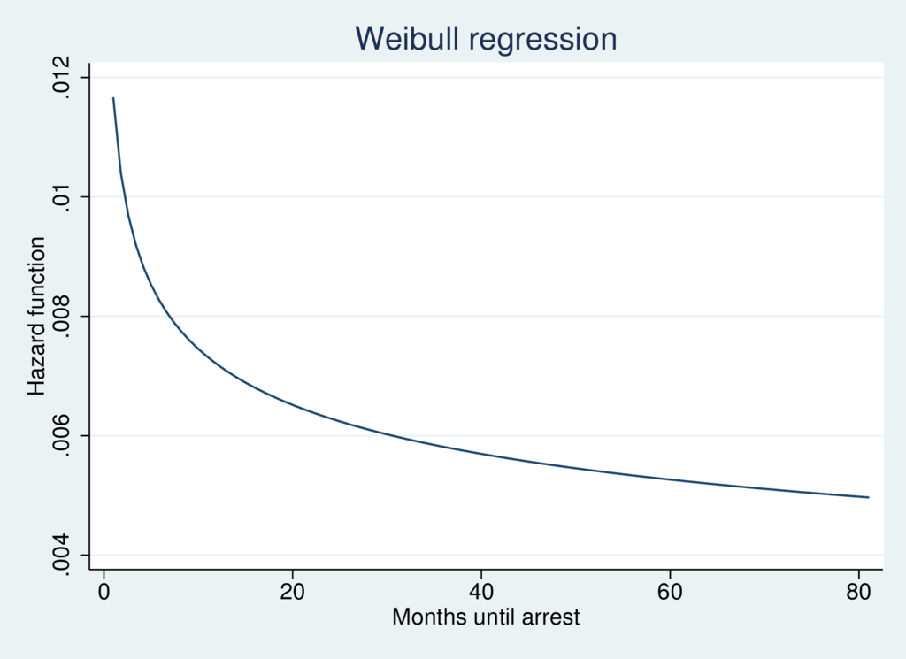

```stata
// Available on https://mitpress.mit.edu/books/econometric-analysis-cross-section-and-panel-data
// or at http://www.stata.com/texts/eacsap/
use recid, clear

stset durat, failure(cens == 0)
streg workprg priors tserved felon alcohol drugs black married educ age, /*
  */ distribution(weibull) nohr

stcurve, hazard saving(recid, replace) xtitle(Months until arrest)
graph use recid
graph export recid_hazard.eps, replace
```

The `nohr` option tells Stata not to display the coefficients exponentiated (as hazard ratios). Now in R

```r
# Loading packages and data
library(foreign)
library(survival)
recid <- read.dta("recid.dta")

# Running the model
ans <- survreg(Surv(durat, event=I(cens == 0)) ~
         workprg + priors + tserved + felon + alcohol + drugs + black +
         married + educ + age, data=recid, dist="weibull")

summary(ans)
```

```
##
## Call:
## survreg(formula = Surv(durat, event = I(cens == 0)) ~ workprg +
##     priors + tserved + felon + alcohol + drugs + black + married +
##     educ + age, data = recid, dist = "weibull")
##                Value Std. Error     z        p
## (Intercept)  4.22167   0.341311 12.37 3.85e-35
## workprg     -0.11278   0.112535 -1.00 3.16e-01
## priors      -0.11018   0.017067 -6.46 1.08e-10
## tserved     -0.01683   0.002130 -7.90 2.78e-15
## felon        0.37162   0.131995  2.82 4.87e-03
## alcohol     -0.55513   0.132243 -4.20 2.69e-05
## drugs       -0.34927   0.121880 -2.87 4.16e-03
## black       -0.56302   0.110817 -5.08 3.76e-07
## married      0.18810   0.135752  1.39 1.66e-01
## educ         0.02891   0.024115  1.20 2.31e-01
## age          0.00462   0.000665  6.95 3.60e-12
## Log(scale)   0.21584   0.038915  5.55 2.92e-08
##
## Scale= 1.24
##
## Weibull distribution
## Loglik(model)= -3192.1   Loglik(intercept only)= -3274.8
##  Chisq= 165.48 on 10 degrees of freedom, p= 0
## Number of Newton-Raphson Iterations: 5
## n= 1445
```

Now, you may be wondering why the estimates seem different. The reason is because, while `Stata`’s estimation method follows Proportional Hazard (PH) equations, `R` uses Accelerated Failure Time (AFT). In Stata we can use the option `time` to use AFT instead (try it yourself!).

In order to do the conversion, from the Stata manual, we see that the survival functions of each method can be written as follows:

$$\begin{align*}
\mbox{PH: } & \exp\left(-\lambda_jt_j^p\right),\quad\mbox{with } \lambda_j=\exp(x_j\beta) \\
\mbox{AFT: } & \exp\left(-\lambda_jt_j^p\right),\quad\mbox{with } \lambda_j=\exp(-px_j\beta)
\end{align*}$$

```r
cbind(
  beta = c(coef(ans)*(-1/ans$scale), `p`=1/ans$scale),
  sd   = sqrt(diag(ans$var))*(1/ans$scale))
```

```
##                     beta           sd
## (Intercept) -3.402093509 0.2750507085
## workprg      0.090889277 0.0906876368
## priors       0.088786675 0.0137540589
## tserved      0.013562467 0.0017167230
## felon       -0.299477494 0.1063701582
## alcohol      0.447361071 0.1065696897
## drugs        0.281460523 0.0982188652
## black        0.453714680 0.0893034704
## married     -0.151586401 0.1093975947
## educ        -0.023298411 0.0194336817
## age         -0.003724612 0.0005357551
## p            0.805864364 0.0313600945
```

At the end, the results are not exactly the same due to the implementation of the algorithm. This is explicitly mentioned in the manual of the `survival` package:

> All the distributions are cast into a location-scale framework, based on chapter 2.2 of Kalbfleisch and Prentice. The resulting parameterization of the distributions is sometimes (e.g. gaussian) identical to the usual form found in statistics textbooks, but other times (e.g. Weibull) it is not. See the book for detailed formulas.

## 22.5.1 Cox’s Partial Likelihood Method for the Proportional Hazard Model

Each individual $i$ has a hazard function specified by the following model $\lambda_i(t) = \exp(\mathbf{x}_i'\beta)\lambda_0(t)$. In the base case, similar to what is done with the Kaplan-Meier model, we assume that each individual has a different survival and hace we can build the cumulative distribution function by, besides of assuming independence between obs, adding up, hence, up to time $T^*$, the cumulative of the hazard function is

$$\Lambda_{T^*}(t) = \sum_{i \in R_i} \exp(\mathbf{x}_i'\beta)\lambda_0(t) =\lambda_0(t) \sum_{i \in R_i}\exp(\mathbf{x}_i'\beta)$$
where $R_i \equiv \{i \in N: T_i \geq T^*\}$. Hence, if we truncate the hazard function (which is a pdf) to that set, we obtain

$$\mathcal{L}_i = \frac{\exp(\mathbf{x}_i'\beta)}{\sum_{i \in R_i}\exp(\mathbf{x}_i'\beta)}$$

## 22.3.4 Unobserved heterogeneity

When to use it:

> The strongest case is seen when we are interested in testing for duration dependence on observed covariates *and* unobserved heterogeneity, when the unobserved heterogeneity enters the hazard multiplicatively (Wooldridge (2010), p. 1006)

Assumptions:

1. the heterogeneity is independent of the observed covariates, as well as starting times and censoring,
2. the heterogeneity has a distribution known up to a finite number of parameters, and
3. the heterogeneity enters the hazard function multiplicatively

Often, when models introduce heterogeneity, these are called mixture models.

```stata
use recid, clear

stset durat, failure(cens==0)
gen id = _n

streg workprg priors tserved felon alcohol drugs black married educ age, /*
    */ distribution(weibull) nohr frailty(gamma)

stcurve, hazard saving(recid_het, replace) xtitle(Months until arrest)
graph use recid_het
graph export recid_het_hazard.eps, replace
```

```
##
## . use recid, clear
##
## .
## . stset durat, failure(cens==0)
##
##      failure event:  cens == 0
## obs. time interval:  (0, durat]
##  exit on or before:  failure
##
## ------------------------------------------------------------------------------
##      1445  total obs.
##         0  exclusions
## ------------------------------------------------------------------------------
##      1445  obs. remaining, representing
##       552  failures in single record/single failure data
##     80013  total analysis time at risk, at risk from t =         0
##                              earliest observed entry t =         0
##                                   last observed exit t =        81
##
## . gen id = _n
##
## .
## . streg workprg priors tserved felon alcohol drugs black married educ age, /*
## >         */ distribution(weibull) nohr frailty(gamma)
##
##          failure _d:  cens == 0
##    analysis time _t:  durat
##
## Fitting Weibull model:
##
## Fitting constant-only model:
##
## Iteration 0:   log likelihood = -1893.9837
## Iteration 1:   log likelihood = -1753.2911  (not concave)
## Iteration 2:   log likelihood = -1730.4123  (not concave)
## Iteration 3:   log likelihood = -1717.5565
## Iteration 4:   log likelihood = -1662.9453
## Iteration 5:   log likelihood = -1656.9105
## Iteration 6:   log likelihood = -1656.8279
```

[output cut: 40 more lines]

```
##          1/p |   .5855198    .055695                      .4859312    .7055184
##        theta |   5.990906   1.071472                      4.219445    8.506084
## ------------------------------------------------------------------------------
## Likelihood-ratio test of theta=0: chibar2(01) =    96.23 Prob>=chibar2 = 0.000
##
## .
## . stcurve, hazard saving(recid_het, replace) xtitle(Months until arrest)
## (option unconditional assumed)
## (file recid_het.gph saved)
##
## . graph use recid_het
##
## . graph export recid_het_hazard.eps, replace
## (note: file recid_het_hazard.eps not found)
## (file recid_het_hazard.eps written in EPS format)
```

And the associated plot

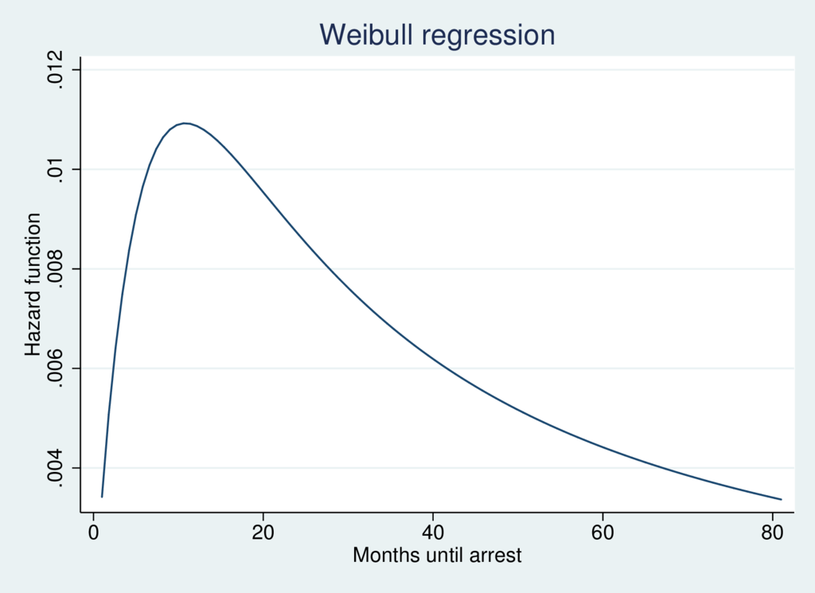

Unfortunately, I haven’t been able to reproduce this example in R. The fardest that I’ve reached is including frailty in the model without much success.

Will review this on the future!

```r
ans <- survreg(
  Surv(durat, event=I(cens == 0)) ~
    workprg + priors + tserved + felon + alcohol + drugs + black +
    married + educ + age +
    frailty(gl(nrow(recid),1)),
  data=recid, dist="weibull")

ans
```

```
## Call:
## survreg(formula = Surv(durat, event = I(cens == 0)) ~ workprg +
##     priors + tserved + felon + alcohol + drugs + black + married +
##     educ + age + frailty(gl(nrow(recid), 1)), data = recid, dist = "weibull")
##
##                           coef     se(coef) se2      Chisq    DF   p
## (Intercept)                3.98069 2.44e-02 2.44e-02  26685.8  1.0 0.0e+00
## workprg                   -0.02935 7.63e-03 7.63e-03     14.8  1.0 1.2e-04
## priors                    -0.06140 1.09e-03 1.09e-03   3155.2  1.0 0.0e+00
## tserved                   -0.00932 1.67e-04 1.67e-04   3124.8  1.0 0.0e+00
## felon                      0.15567 1.12e-02 1.12e-02    193.5  1.0 0.0e+00
## alcohol                   -0.29792 7.66e-03 7.66e-03   1510.8  1.0 0.0e+00
## drugs                     -0.13422 8.29e-03 8.29e-03    261.9  1.0 0.0e+00
## black                     -0.19954 8.20e-03 8.20e-03    591.9  1.0 0.0e+00
## married                    0.11944 1.19e-02 1.19e-02    101.0  1.0 0.0e+00
## educ                       0.00745 1.75e-03 1.75e-03     18.1  1.0 2.1e-05
## age                        0.00196 3.65e-05 3.65e-05   2874.4  1.0 0.0e+00
## frailty(gl(nrow(recid), 1                            761049.7 33.4 0.0e+00
##
## Scale= 0.274
##
## Iterations: 10 outer, 54 Newton-Raphson
##      Variance of random effect= 1.6   I-likelihood = -929.8
## Degrees of freedom for terms=  1.0  1.0  1.0  1.0  1.0  1.0  1.0  1.0  1.0  1.0  1.0 33.4  NaN
## Likelihood ratio test=2604  on NaN df, p=NaN  n= 1445
```

# References

StataCorp. 2001. *Stata 12 Base Reference Manual*. Stata Press.

Therneau, Terry M. 2016. *Survival: Survival Analysis*. https://CRAN.R-project.org/package=survival.

Wooldridge, Jeffrey M. 2010. *Econometric Analysis of Cross Section and Panel Data*. 2nd ed. Cambridge: MIT Press.